# Assignment 4

Brian Yoo

2022-11-01

### Abstract

This report recalls the dataset that contains information on the United State jails. The dataset contains the different kinds of population in jail and other counts/rates related to the US prison.

### Introduction

The data from this report can reveal patterns of inequality. The total imprisonment value of certain groups of people may proportionately differ and there may be a significant gap between certain groups who are susceptible to imprisonment. It also tackles the issue of incarceration. In certain years, there are more imprisonment in certain locations. It’s important to understand why this happened and if there is a solution that can be established from the dataset. The dataset provides more than just information on jail counts. It provides other essential details such as the deaths in custody reporting program (DCRP), which helps identify if there is any disproportionality within the population. The direct stakeholders may be the people who are imprisoned; the report from this data is directly focused on them and the attention may impact their treatment in the future. The indirect stakeholders include reporters using this dataset to update news on this topic, law enforcement who need to be cautious of who they arrest, and the US government court who makes the final decision on someone’s imprisonment.

### Data Summary

```r
library(dplyr)
library(tidyr)
library(tidyverse)
trend <- read.csv("https://raw.githubusercontent.com/vera-institute/incarceration-trends/master/incarceration_trends.csv")
state_highest_black <- trend %>%
  filter(black_jail_pop == max(na.omit(black_jail_pop))) %>%
  pull(state)
```

```r
highest_pop<- trend %>%
  filter(total_jail_pop == max(na.omit(total_jail_pop))) %>%
  pull(total_jail_pop)

highest_pop_year <- trend %>%
  filter(total_jail_pop == max(na.omit(total_jail_pop))) %>%
  pull(year)
```

```r
dcrp_state <- trend %>%
  filter(total_jail_pop_dcrp == max(na.omit(total_jail_pop_dcrp))) %>%
  pull(state)

dcrp_county <- trend %>%
  filter(total_jail_pop_dcrp == max(na.omit(total_jail_pop_dcrp))) %>%
  pull(county_name)
```

### Growth of the U.S. Prison Population

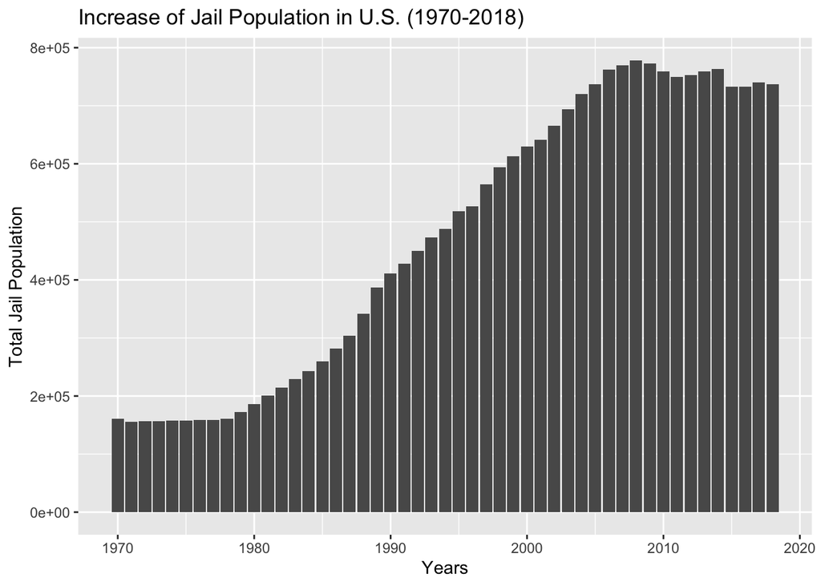

### Growth of Prison Population by State

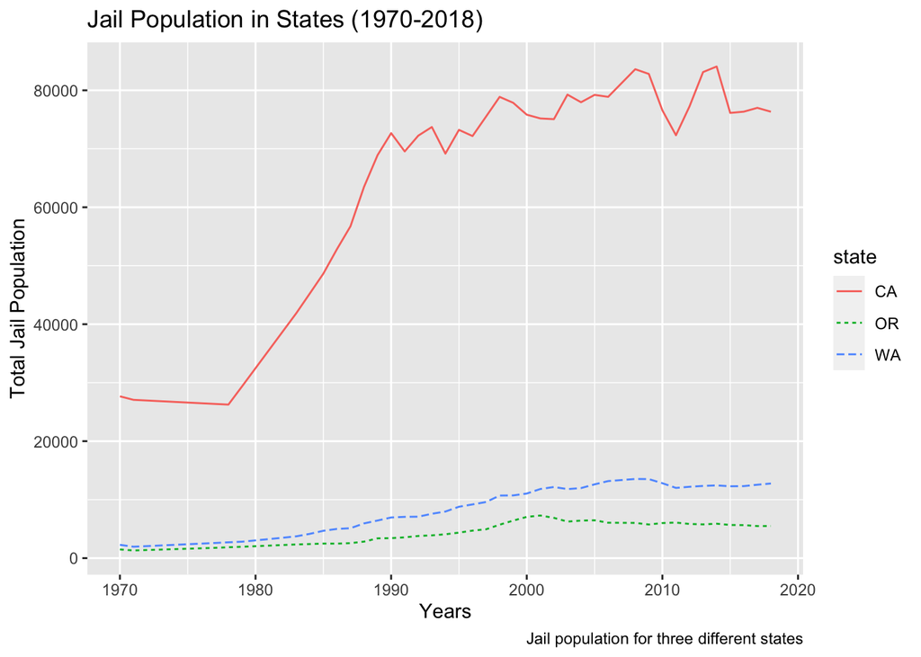

### Variable Comparison that Reveals Potential Patterns of Inequality

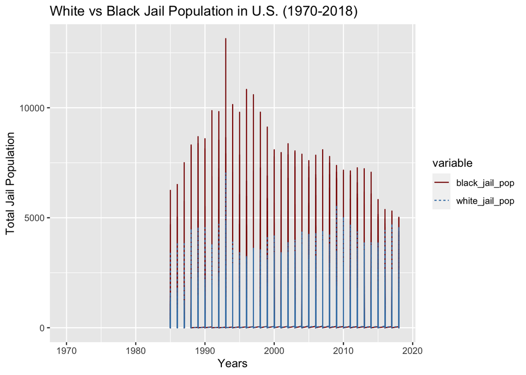

This chart shows the comparison between the total population of black people in jail vs the total population of white people in jail. The chart shows that the black population has significantly more number, than the white population. The white population is represented by dotted blue lines, while the black population is represented by red solid lines.

### A Map that Shows Potential Patterns of Inequality that Vary Geographically